# Exam 2016

Ninette Lotter

31 August 2016

## Question 1

**Alternative hypothesis:** Body temperature and heart rate is different between men and women

**Null hypothesis:** There is no difference in body temperature or heart rate between men and women.

```r
# Load packages
library(tidyr)
library(dplyr)
```

```r
library(ggplot2)
# Import data
data1 <- readr::read_csv('https://dl.dropboxusercontent.com/u/11805474/painblogr/biostats/exam-data-2016/question1.csv')
# Summary statistics
summary(data1)
```

```
##  body_temperature      male           female
##  Min.   :35.70    Min.   :58.00   Min.   :57.00
##  1st Qu.:36.60    1st Qu.:70.00   1st Qu.:68.00
##  Median :36.80    Median :73.00   Median :76.00
##  Mean   :36.81    Mean   :73.37   Mean   :74.15
##  3rd Qu.:37.10    3rd Qu.:78.00   3rd Qu.:80.00
##  Max.   :38.20    Max.   :86.00   Max.   :89.00
##                   NA's   :65      NA's   :65
```

```r
head(data1)
```

```
## Source: local data frame [6 x 3]
##
##   body_temperature  male female
##              (dbl) (int)  (int)
## 1             35.7    70     NA
## 2             35.8    NA     69
## 3             35.9    71     NA
## 4             35.9    NA     62
## 5             36.0    NA     75
## 6             36.1    74     NA
```

```r
# TIdy data
gathered1 <- gather(data1, key = Sex, value = Heart_rate, male:female, na.rm = T)
gathered1
```

```
## Source: local data frame [130 x 3]
##
##    body_temperature   Sex Heart_rate
##               (dbl) (chr)      (int)
## 1              35.7  male         70
## 2              35.9  male         71
## 3              36.1  male         74
## 4              36.1  male         80
## 5              36.2  male         73
## 6              36.2  male         75
## 7              36.2  male         82
## 8              36.2  male         64
## 9              36.3  male         69
## 10             36.3  male         70
## ..              ...   ...        ...
```

```r
summary(gathered1)
```

```
##  body_temperature     Sex              Heart_rate
##  Min.   :35.70    Length:130         Min.   :57.00
##  1st Qu.:36.60    Class :character   1st Qu.:69.00
##  Median :36.80    Mode  :character   Median :74.00
##  Mean   :36.81                       Mean   :73.76
##  3rd Qu.:37.10                       3rd Qu.:79.00
##  Max.   :38.20                       Max.   :89.00
```

```r
# Perform statistical test
t.test(body_temperature ~ Sex, data = gathered1, paired = T)
```

```
##
##  Paired t-test
##
## data:  body_temperature by Sex
## t = 11.536, df = 64, p-value < 2.2e-16
## alternative hypothesis: true difference in means is not equal to 0
## 95 percent confidence interval:
##  0.1348352 0.1913186
## sample estimates:
## mean of the differences
##               0.1630769
```

```r
t.test(Heart_rate ~ Sex, data = gathered1, paired = T)
```

```
##
##  Paired t-test
##
## data:  Heart_rate by Sex
## t = 0.57697, df = 64, p-value = 0.566
## alternative hypothesis: true difference in means is not equal to 0
## 95 percent confidence interval:
##  -1.932058  3.501289
## sample estimates:
## mean of the differences
##               0.7846154
```

**Type of data:** Paired continuous data.

**Test Assumptions:**

- Data are normally distributed.
- Equal variance across groups.
- The errors are independent.
- Matching is effective.

**Statistical test:** t-test

**Test statistic:**

*Heart rate ~ Sex* t = 0.577 p =0.566 95% CI = -1.93 to 3.501

*Body temperature ~ Sex* t = 11.536 p < 0.001

## Question 2

**Alternative hypothesis:** Handedness is associated with ataxic walking in intoxicated individuals.

**Null hypothesis:** There is no association between handedness and ataxic walking in intoxicated individuals.

```r
# load packages
library(tidyr)
library(dplyr)
# Import data
data2 <- readr::read_csv('https://dl.dropboxusercontent.com/u/11805474/painblogr/biostats/exam-data-2016/question2.csv')
# Summary statistics
summary(data2)
```

```
##        id             sex           handedness     first_stumble
##  Min.   :  1.0   Min.   :0.0000   Min.   :0.0000   Min.   :0.0000
##  1st Qu.: 38.5   1st Qu.:0.0000   1st Qu.:0.0000   1st Qu.:0.0000
##  Median : 76.0   Median :0.0000   Median :0.0000   Median :0.0000
##  Mean   : 76.0   Mean   :0.4503   Mean   :0.4967   Mean   :0.4967
##  3rd Qu.:113.5   3rd Qu.:1.0000   3rd Qu.:1.0000   3rd Qu.:1.0000
##  Max.   :151.0   Max.   :1.0000   Max.   :1.0000   Max.   :1.0000
##  final_position
##  Min.   :0.0000
##  1st Qu.:0.0000
##  Median :1.0000
##  Mean   :0.5563
##  3rd Qu.:1.0000
##  Max.   :1.0000
```

```r
head(data2)
```

```
## Source: local data frame [6 x 5]
##
##      id   sex handedness first_stumble final_position
##   (int) (int)      (int)         (int)          (int)
## 1     1     1          1             1              1
## 2     2     1          1             1              1
## 3     3     0          1             1              1
## 4     4     1          1             1              0
## 5     5     1          1             0              0
## 6     6     1          0             0              1
```

```r
# Select a subset of columns
select <- select(data2, handedness, final_position)
# Cross tabulate selected columns
tab <- xtabs(~ handedness + final_position, data = select)
tab
```

```
##           final_position
## handedness  0  1
##          0 40 36
##          1 27 48
```

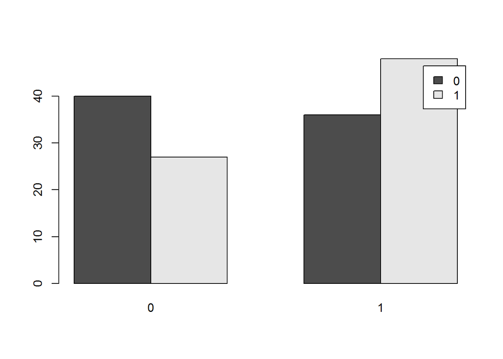

```r
# Plot data
barplot(tab, beside = TRUE, legend.text = TRUE)
```

```r
# Statistical test
mcnemar.test(tab)
```

```
##
##  McNemar's Chi-squared test with continuity correction
##
## data:  tab
## McNemar's chi-squared = 1.0159, df = 1, p-value = 0.3135
```

**Type of data:** Paired ordinal data.

**Test Assumptions:**

- The two groups are mutually independent.
- Each x and y can be assigned to two possible categories.
- Random sampling.

**Statistical test:** McNemar Test

**Test statistic:**

Chi-squared = 1.0159 Degrees of freedom = 1 Sample size = 151 p = 0.3135

**Conclusion:** There is no significant association (Chi-squared = 1.0159, p = 0.3135) between handedness and ataxic walking in intoxicated individuals.

## Question 3

**Alternative hypothesis:** Running time is associated with calories consumed during a run.

**Null hypothesis:** There is no association between running time and calorie consumption.

```r
# Load packages
library(readr)
library(tidyr)
# Import dataset
data3 <- readr::read_csv('https://dl.dropboxusercontent.com/u/11805474/painblogr/biostats/exam-data-2016/question3.csv')
# Summary statistics
summary(data3)
```

```
##       run            time         calories
##  Min.   : 1.0   Min.   :1879   Min.   :302.0
##  1st Qu.: 5.5   1st Qu.:1943   1st Qu.:340.5
##  Median :10.0   Median :2019   Median :373.0
##  Mean   :10.0   Mean   :2026   Mean   :371.6
##  3rd Qu.:14.5   3rd Qu.:2100   3rd Qu.:399.0
##  Max.   :19.0   Max.   :2174   Max.   :446.0
```

```r
head(data3)
```

```
## Source: local data frame [6 x 3]
##
##     run  time calories
##   (int) (int)    (int)
## 1     1  2169      319
## 2     2  1986      384
## 3     3  1979      398
## 4     4  1937      359
## 5     5  2093      366
## 6     6  1924      388
```

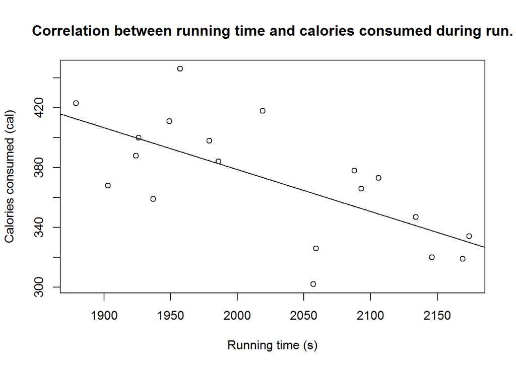

```r
# Exploratory plot (modified to publishable format)
plot(data3$time, data3$calories, xlab = 'Running time (s)', ylab = 'Calories consumed (cal)', main = 'Correlation between running time and calories consumed during run.')
# Abline of linear regression
abline(lm(calories ~ time, data = data3))
```

```r
# Test for correlation
cor.test(data3$time, data3$calories, method = 'pearson')
```

```
##
##  Pearson's product-moment correlation
##
## data:  data3$time and data3$calories
## t = -3.7715, df = 17, p-value = 0.001522
## alternative hypothesis: true correlation is not equal to 0
## 95 percent confidence interval:
##  -0.8642170 -0.3183295
## sample estimates:
##        cor
## -0.6749491
```

```r
# Linear regression analysis
model <- lm(calories ~ time, data = data3)
# Print summary of linear regression statistics
summary(model)
```

```
##
## Call:
## lm(formula = calories ~ time, data = data3)
##
## Residuals:
##    Min     1Q Median     3Q    Max
## -60.76 -15.09   4.04  15.67  55.21
##
## Coefficients:
##              Estimate Std. Error t value Pr(>|t|)
## (Intercept) 939.36422  150.70365   6.233 9.09e-06 ***
## time         -0.28031    0.07432  -3.772  0.00152 **
## ---
## Signif. codes:  0 '***' 0.001 '**' 0.01 '*' 0.05 '.' 0.1 ' ' 1
##
## Residual standard error: 30.17 on 17 degrees of freedom
## Multiple R-squared:  0.4556, Adjusted R-squared:  0.4235
## F-statistic: 14.22 on 1 and 17 DF,  p-value: 0.001522
```

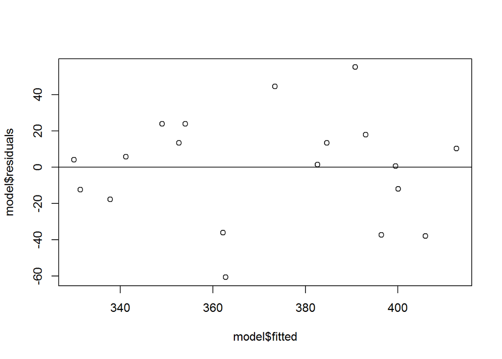

```r
# Diagnostic plots to confirm linear regression
plot(x = model$fitted, y = model$residuals)
abline(h = 0)
```

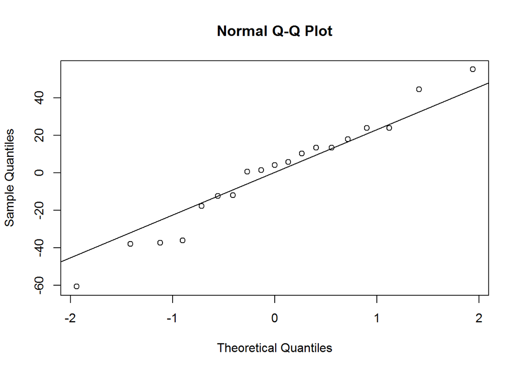

```r
qqnorm(model$residuals)
qqline(model$residuals)
```

**Type of data:** Unpaired continuous data.

**Assumptions for Pearson’s correlation:**

- There is a linear relationship between the variables.
- There are no outliers
- Both variables are approximately normally distributed.

**Assumptions for linear regression:**

- There is a linear trend between x and y.
- The observations in the sample are independent.
- x is measured without error.
- The residuals are normally distributed.
- The residuals have the same variance for all fitted values of y (homoskedastic).

**Statistical test:** Pearson’s correlation and linear regression model.

**Results:**

*Correlation analysis* Pearson’s t = -3.77 Degrees of freedom = 17 p = 0.0015 95% Confidence Interval = -0.86 to -0.32

*Linear regression* F-statistic = 14.22 Degrees of freedom = 17 p = 0.0015

The graph fitted for homoskedacity shows no pattern, therefore the residuals have the same variance for all fitted values of y. The quantile-quantile plot showed a Gaussian distribution of the residuals.

**Conclusion:** There is a significant inverse relationship (t = -3.77, F = 14.22, p = 0.0015) between running time and the calories consumed during a run.

## Question 4

```r
library(readr)
library(tidyr)
foo <- rnorm(10000, mean = 60, sd = 3) # final mark
bar <- rnorm(10000, mean = 68, sd = 5) # project mark
baz <- rep(seq(from = 1997, to = 2006), each = 1) # years

year <- sample(baz, 150, replace = TRUE,
               prob = c(0.05, 0.05, 0.08, 0.08,
                          0.1, 0.13, 0.14, 0.13, 0.12, 0.12))
project_mark <- sample(bar, 150, replace = TRUE)
final_mark <- sample(foo, 150, replace = TRUE)

plot_data <- data_frame(year = year,
                        project_mark = round(project_mark, 1),
                        final_mark = round(final_mark, 1)) %>%
    arrange(year)
plot(plot_data$project_mark, plot_data$final_mark, xlab = 'Project mark (%)', ylab = 'Final mark (%)', main = 'Relationship between project mark and final mark.', ylim = c(50, 80), xlim = c(50, 80))
```

[figure not shown]

```r
# Axis scale was set from 50 to 80 because the distribution and trend of the marks is easier to see.
```